# funcml

`funcml` provides a formula-first workflow for fitting and evaluating models. The package also includes native interpretability helpers for permutation importance, partial dependence, ICE, ALE, local surrogate explanations, SHAP, interaction strength, greedy breakdown profiles, and global surrogate models. It also exposes native ensemble learners through `model = "stacking"` and `model = "superlearner"`.

The package is intentionally opinionated. It is not designed to compete feature for feature with broader frameworks such as `tidymodels`, `mlr3`, or `caret`. Instead, `funcml` focuses on a compact, explicit, formula-first workflow for users who want to fit, compare, tune, interpret, and estimate models through one coherent interface.

This design comes with a deliberate tradeoff:

- preprocessing is expected to happen outside `funcml`, so the data passed to `fit()` is the exact data being modeled
- the package favors functional composition and explicit inputs over hidden preprocessing state inside training workflows
- cross-validation is still the default, but the package also supports holdout splits, grouped CV, and time-aware rolling evaluation through the same resampling interface

Users who need broader preprocessing orchestration or specialized resampling designs should use a more complete framework.

Learner coverage currently includes:

- regression and classification: `glm`, `rpart`, `glmnet`, `ranger`, `nnet`, `e1071_svm`, `randomForest`, `gbm`, `kknn`, `ctree`, `cforest`, `lightgbm`, `catboost`, `xgboost`, `stacking`, `superlearner`
- regression and binary classification: `earth`, `gam`, `bart`
- classification only: `C50`, `naivebayes`, `fda`, `lda`, `qda`
- binary classification only: `adaboost`
- regression only: `pls`

```r
fit_obj <- fit(mpg ~ wt + hp, data = mtcars, model = "glm")

permute_obj <- interpret(fit_obj, mtcars, method = "permute", nsim = 5)
pdp_obj <- interpret(fit_obj, mtcars, method = "pdp", features = "wt")
ale_obj <- interpret(fit_obj, mtcars, method = "ale", features = "wt")
local_obj <- interpret(fit_obj, mtcars, method = "local_model", newdata = mtcars[1, , drop = FALSE], k = 2)
shap_obj <- interpret(fit_obj, mtcars, method = "shap", newdata = mtcars[1, , drop = FALSE], nsim = 20)
profile_obj <- interpret(fit_obj, mtcars, method = "profile", newdata = mtcars[1, , drop = FALSE])
surrogate_obj <- interpret(fit_obj, mtcars, method = "surrogate")
```

```r
eval_obj <- evaluate(mpg ~ wt + hp, data = mtcars, model = "glm", resampling = holdout(prop = 0.8, seed = 1))
eval_obj$summary
```

```
#>   metric      mean sd n std_error conf_level conf_low conf_high
#> 1   rmse 3.6340262 NA 1        NA       0.95       NA        NA
#> 2    mae 3.1375807 NA 1        NA       0.95       NA        NA
#> 3    rsq 0.4102465 NA 1        NA       0.95       NA        NA
```

```r
tune_grid <- expand.grid(intercept = c(TRUE, FALSE))
tune_obj <- tune(mpg ~ wt + hp, data = mtcars, model = "glm", grid = tune_grid, search = "random", n_evals = 1, resampling = cv(v = 3, seed = 1), seed = 1)
tune_obj$best
```

```
#>   intercept     mean        sd n std_error conf_level  conf_low conf_high
#> 1      TRUE 2.772583 0.9774437 3 0.5643274       0.95 0.3444783  5.200688
```

Nested CV is available through `outer_resampling`. The inner `resampling` argument still selects the best configuration, and the outer resampling loop provides an unbiased estimate of tuned workflow performance.

```r
nested_tune_obj <- tune(
  mpg ~ wt + hp,
  data = mtcars,
  model = "glm",
  grid = tune_grid,
  resampling = cv(v = 3, seed = 1),
  outer_resampling = cv(v = 4, seed = 2),
  metric = "rmse",
  seed = 1
)
nested_tune_obj$nested$summary
```

[output not shown]

```r
interaction_obj <- interpret(fit_obj, mtcars, method = "interaction")
plot(interaction_obj)
```

[output not shown]

```r
learners()[1:10]
```

```
#>  [1] "glm"          "rpart"        "glmnet"       "ranger"       "nnet"
#>  [6] "e1071_svm"    "randomForest" "gbm"          "C50"          "kknn"
```

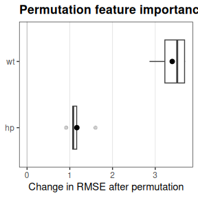

```r
plot(permute_obj)
```

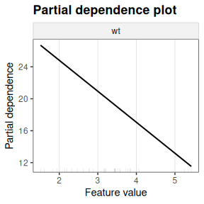

```r
plot(pdp_obj)
```

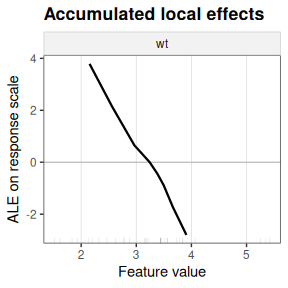

```r
plot(ale_obj)
```

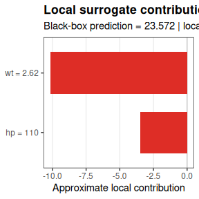

```r
plot(local_obj)
```

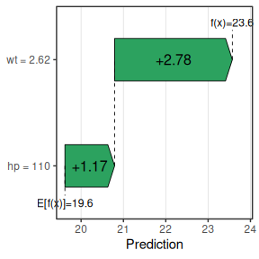

```r
plot(shap_obj, kind = "waterfall")
```

[figure not shown]

```r
plot(profile_obj)
```

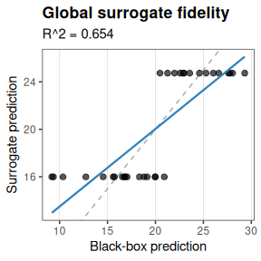

```r
plot(surrogate_obj)
```